# Análise de Sobrevivência

2026-05-25

## Questão 4 - Capítulo

A tabela 4.12 mostra os tempos de sobrevida, em meses, de pacientes com a mesma doença os quais foram submetidos aos tratamentos A ou B. O símbolo + indica censura.

Considerando a covariável \(X = tratamento\), em que \(X=0\) se tratamento A e \(X=1\) se tratamento B.

| Tratamento - Tempo de Sobrevida em Meses |
| --- |
| A 1 2 2 2 2+ 6 8 8 9 9+ 13 13+ 16 17 22+ 25+ 29 34 36 43+ 45+ |
| B 1 2 5 7 7+ 11+ 12 19 22 30 35+ 39 42 46 55 |

## Questão

1. Ajuste os modelos de regressão exponencial, de Weibull e log-normal e selecione o mais adequado aos dados.
2. Com base no modelo selecionado em (a), utilize o teste da razão de verossimilhanças para testar se os tratamentos A e B diferem.
3. Para o modelo selecionado, apresente a análise gráfica dos resíduos e a(s) curva(s) de sobrevivência estimada(s).
4. Com base no modelo selecionado, estime e interprete a sobrevivência em t = 40 meses

## Inserindo os Dados no R

1. Ajuste os modelos de regressão exponencial, de Weibull e log-normal e selecione o mais adequado aos dados.

```r
library(survival)
library(flexsurv)
# Tratamento A
tempo_A <- c(1,2,2,2,2,6,8,8,9,9,13,13,16,17,22,25,29,34,36,43,45)
status_A <- c(1,1,1,1,0,1,1,1,1,0,1,0,1,1,0,0,1,1,1,0,0) # 1 = falha
trat_A <- rep(0,length(tempo_A))

# Tratamento B
tempo_B <- c(1,2,5,7,7,11,12,19,22,30,35,39,42,46,55)
status_B <- c(1,1,1,1,0,0,1,1,1,1,0,1,1,1,1)
trat_B <- rep(1,length(tempo_B))
```

## Junção dos Dados

```r
tempo <- c(tempo_A, tempo_B)
status <- c(status_A, status_B)
trat <- c(trat_A, trat_B)

dados <- data.frame(tempo = tempo,status = status,tratamento = trat)
Surv_obj <- Surv(time = dados$tempo,event = dados$status)
mod_exp <- survreg(Surv_obj ~ tratamento, data = dados,
                   dist = "exponential")
```

## Modelo Exponencial

```r
summary(mod_exp)
```

```
##
## Call:
## survreg(formula = Surv_obj ~ tratamento, data = dados, dist = "exponential")
##             Value Std. Error     z      p
## (Intercept) 3.196      0.267 11.96 <2e-16
## tratamento  0.127      0.393  0.32   0.75
##
## Scale fixed at 1
##
## Exponential distribution
## Loglik(model)= -110.6   Loglik(intercept only)= -110.7
##  Chisq= 0.11 on 1 degrees of freedom, p= 0.75
## Number of Newton-Raphson Iterations: 4
## n= 36
```

## Modelo Exponencial

```r
summary(mod_exp)
```

O modelo exponencial AFT ajustado indica que o grupo tratamento apresenta um tempo de sobrevivência estimado aproximadamente 13,5% maior que o grupo controle (TR ≈ 1.14). Entretanto, esse efeito não é estatisticamente significativo (p = 0.75), sugerindo ausência de evidência de diferença entre os grupos.

O intercepto indica um tempo basal de sobrevivência de aproximadamente 24.4 unidades de tempo para o grupo controle. Como esperado para o modelo exponencial no survreg, o parâmetro de escala é fixo em 1, não sendo estimado.

## Modelo Weibull

```r
summary(mod_weib <- survreg(Surv_obj ~ tratamento,data = dados,
  dist = "weibull"))
```

```
##
## Call:
## survreg(formula = Surv_obj ~ tratamento, data = dados, dist = "weibull")
##               Value Std. Error     z      p
## (Intercept)  3.1945     0.2592 12.33 <2e-16
## tratamento   0.1319     0.3821  0.35   0.73
## Log(scale)  -0.0309     0.1623 -0.19   0.85
##
## Scale= 0.97
##
## Weibull distribution
## Loglik(model)= -110.6   Loglik(intercept only)= -110.7
##  Chisq= 0.12 on 1 degrees of freedom, p= 0.73
## Number of Newton-Raphson Iterations: 5
## n= 36
```

## Modelo Weibull

```r
summary(mod_weib <- survreg(Surv_obj ~ tratamento,data = dados,
  dist = "weibull"))
```

O modelo Weibull AFT ajustado indica que o grupo tratamento apresenta um tempo de sobrevivência estimado aproximadamente 14% maior que o grupo controle (TR ≈ 1.14). Entretanto, esse efeito não é estatisticamente significativo (p = 0.73), não havendo evidência de diferença entre os grupos. O intercepto indica um tempo basal de sobrevivência de aproximadamente 24.4 unidades de tempo para o grupo controle.

O parâmetro de escala estimado (σ ≈ 0.97) não difere significativamente de 1 (p = 0.85), sugerindo que a forma da distribuição Weibull é adequada sem necessidade de ajustes adicionais.

## Modelo Log-normal

```r
mod_lognormal <- survreg(Surv_obj ~ tratamento, data = dados,
                         dist = "lognormal")
summary(mod_lognormal)
```

```
##
## Call:
## survreg(formula = Surv_obj ~ tratamento, data = dados, dist = "lognormal")
##             Value Std. Error    z      p
## (Intercept) 2.671      0.318 8.40 <2e-16
## tratamento  0.189      0.480 0.39  0.694
## Log(scale)  0.295      0.142 2.09  0.037
##
## Scale= 1.34
##
## Log Normal distribution
## Loglik(model)= -111.8   Loglik(intercept only)= -111.9
##  Chisq= 0.15 on 1 degrees of freedom, p= 0.69
## Number of Newton-Raphson Iterations: 3
## n= 36
```

## Modelo Log-normal

```r
mod_lognormal <- survreg(Surv_obj ~ tratamento, data = dados,
                         dist = "lognormal")
summary(mod_lognormal)
```

O modelo lognormal AFT indica que o grupo tratamento apresenta um tempo de sobrevivência estimado aproximadamente 21% maior que o grupo controle (TR ≈ 1.21). No entanto, esse efeito não é estatisticamente significativo (p = 0.69), não havendo evidência de diferença entre os grupos. O intercepto indica um tempo central de sobrevivência de aproximadamente 14.5 unidades de tempo para o grupo controle.

O parâmetro de escala (σ ≈ 1.34) é estatisticamente significativo (p = 0.037), indicando elevada variabilidade nos log-tempos de sobrevivência, o que sugere uma distribuição mais dispersa dos tempos de vida.

## Critérios de Avaliação e Comparação do Modelo

```r
AIC(mod_exp, mod_weib, mod_lognormal)
```

```
##               df      AIC
## mod_exp        2 225.2388
## mod_weib       3 227.2030
## mod_lognormal  3 229.6739
```

```r
BIC(mod_exp, mod_weib, mod_lognormal)
```

```
##               df      BIC
## mod_exp        2 228.4058
## mod_weib       3 231.9536
## mod_lognormal  3 234.4245
```

## Teste de Verossimilhança

O melhor modelo ajustado, levando em conta BIC e AIC, não apresenta melhora significativa em relação ao modelo sem covariáveis, conforme o teste de razão de verossimilhança (p = 0.75).

[figure not shown]

## Análise Gráfica dos Resíduos

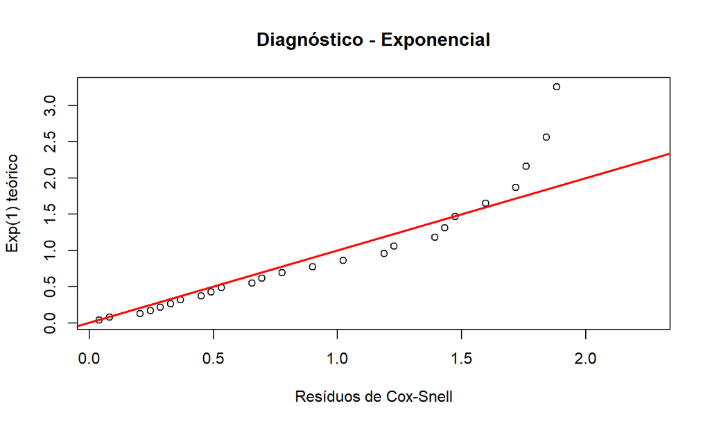

## Estimando t = 40 meses

Para estimar a probabilidade do indivíduo sobreviver além de 40 meses, temos:

\(log(T) = \beta_0 + \beta_1*tratamento\), com intercepto \(= 3.196\) e tratamento \(= 0.127\)

Convertendo para escala de sobrevivência

\(S(t) = exp(-\frac{t}{\mu})\) onde \(\mu = exp(\eta)\)

No grupo controle (tratamento \(= 0\)), a média da sobrevivência é \(\eta_0=3.196\) e \(\mu_0= exp^{3.196} = 24.4\). Então

\(S_0(40) = exp(-\frac{40}{24.4}) = exp(-1.639) = 0.194 = 19.4\%\)